# Exploring US Wealth

## Introduction

### Background

- **Wealth** and **Income** are two distinct measures of an individual’s financial situation.
  - **Wealth** = total value of an individual’s assets (including cash, investments, real estate, and other possessions, minus liabilities such as debt)
  - **Income** = amount of money an individual earns (e.g. from employment, investments, or other sources)
- In general, **wealth** and **income** percentiles are not directly comparable because a high **income** does not necessarily translate to a high level of **wealth**.
- Analyzing data on disparities of household **Wealth** has important implications for businesses and society, including:
  - Informing business strategies
  - Understandiing the financial situation of potential customers
  - Helping policymakers and advocates address **Wealth** inequality
  - Promoting economic opportunities for all.

### This Project

Below are a series of visualizations exploring the distribution of US wealth across wealth percentile groups, income percentile groups, education levels, and generation. These visuals were created with quarterly data from the third quarter of 1989 to the third quarter of 2022 gathered by the US Census Bureau.

## Amount of Wealth

### By Wealth Percentiles

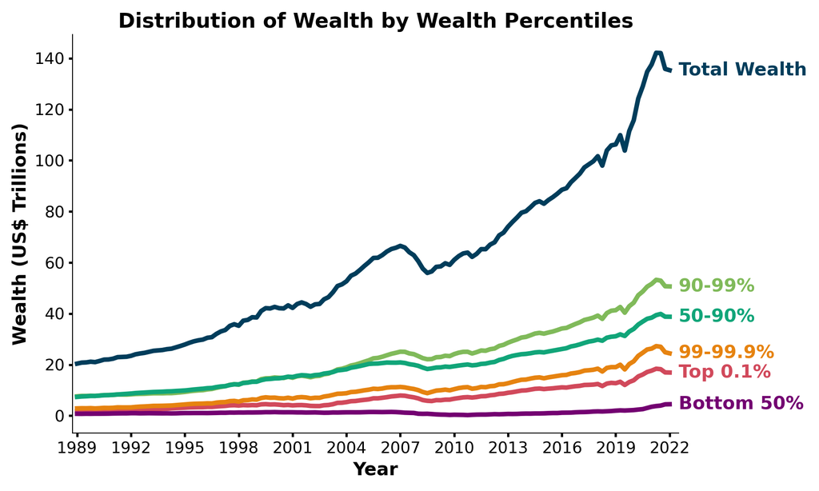

**About this Figure** (click me)**

This plot represents US wealth in trillions of dollars from Quarter 3 in 1989 to Quarter 3 in 2022. Each color represents a specific wealth percentiles group in addition to total wealth. As we can see, the distribution of wealth is unequal, with the bottom 50th percentile consistently accounting for the smallest amount of wealth is the US.

### By Income Percentiles

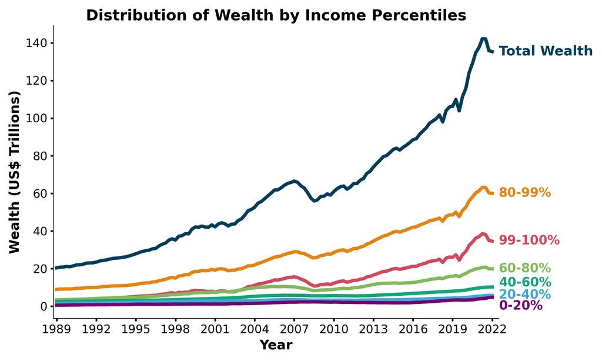

**About this Figure** (click me)**

This plot represents US wealth in trillions of dollars from Quarter 3 in 1989 to Quarter 3 in 2022 by Income percentile groups, in addition to the total of US Wealth. As seen on the plot, the distribution of wealth is unequal, with the groups in bottom 60th percentiles consistently showing the smallest amount of growth in wealth. An additional interesting note, we can see that the top 1% (99-100%) and the top 20% (80-99%) income percentiles groups share very similar trends over time, with the latter consistently maintaining nearly twice as much wealth.

### By Education

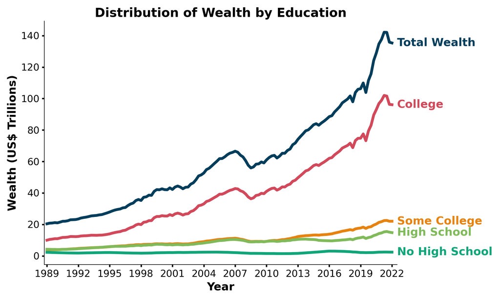

**About this Figure** (click me)**

### By Generation

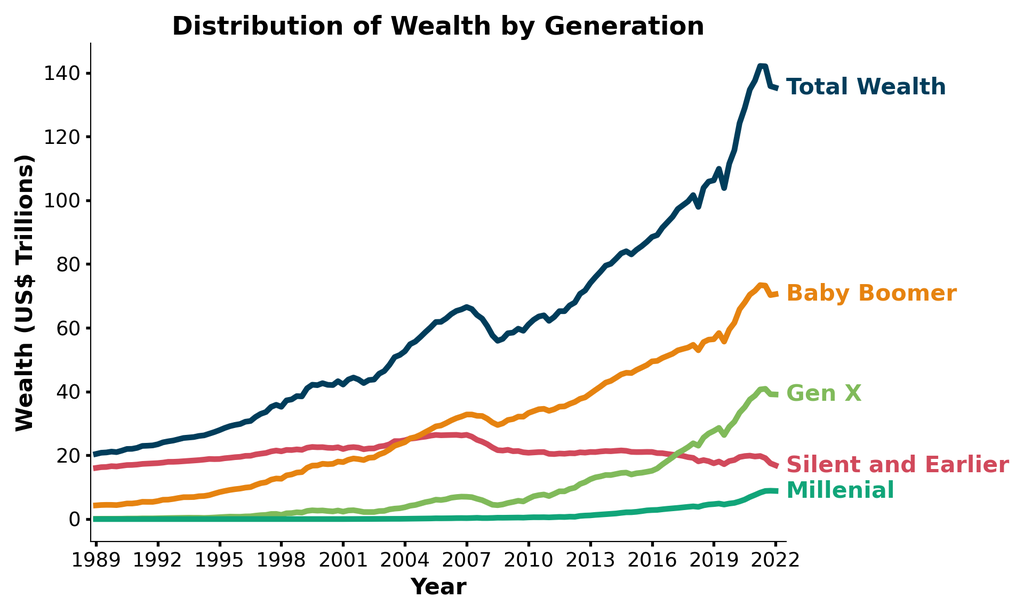

**About this Figure** (click me)**

This plot represents US wealth in trillions of dollars from 1989 to 2022. Each color represents a generation in addition to total wealth of the US. As we can see, the rate of change in wealth over time is not equitable across generations, with the Silent and Earlier and Millennial generations showing relatively stable amounts of wealth over time. This is likely related to age, as the Silent and Earlier generation has aged into retirement during this period while the Millennial have only recently reached young to middle adulthood. The Baby Boomer and Gen X show very similar patterns of growth over time.

## Proportion of Wealth

### By Wealth Percentiles

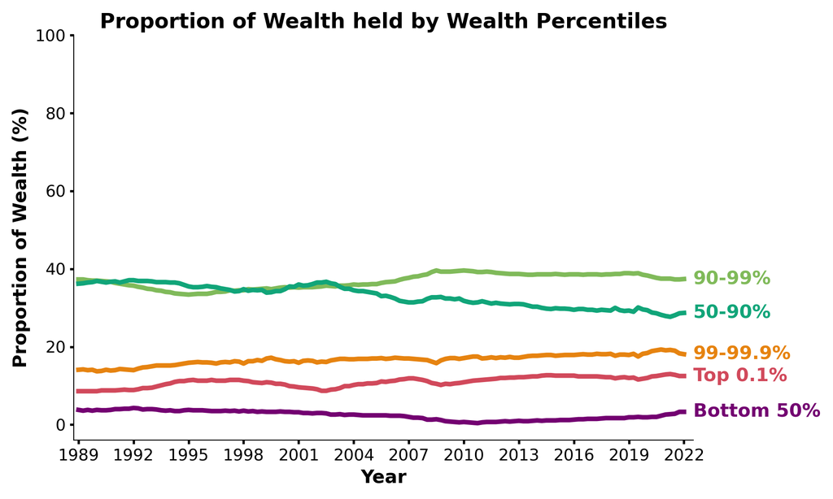

**About this Figure** (click me)**

### By Income Percentiles

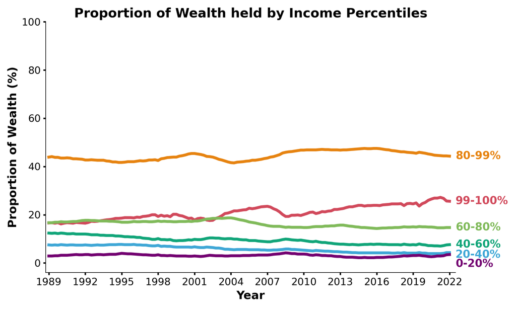

**About this Figure** (click me)**

This plot represents the percentage of US Wealth held by Income Percentiles from Quarter 3 in 1989 to Quarter 3 in 2022. Based on this plot, there is a large gap between the proportion of wealth held by those in the 80-99% Income Percentiles versus those in the 0-40% Income Percentile. The disparity maintained an approximate 37% difference between these two Income percentile groups since Quarter 3 in 1989. Another interesting trend we noted for the Top 1% (99-100%) Income percentile group, was a clear increase from the start of 2020 to the 2022.

### By Education

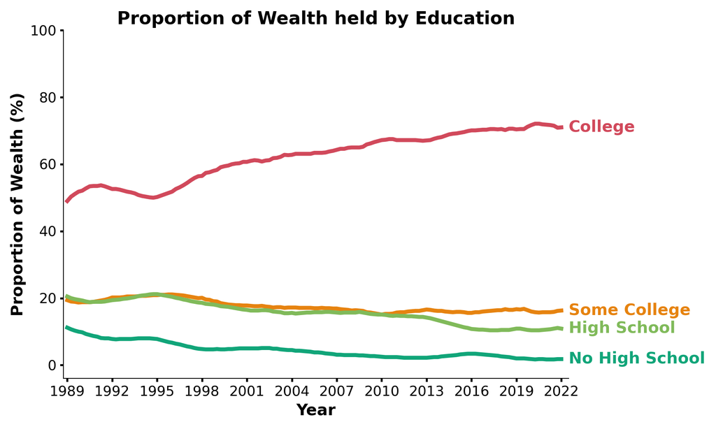

**About this Figure** (click me)**

### By Generation

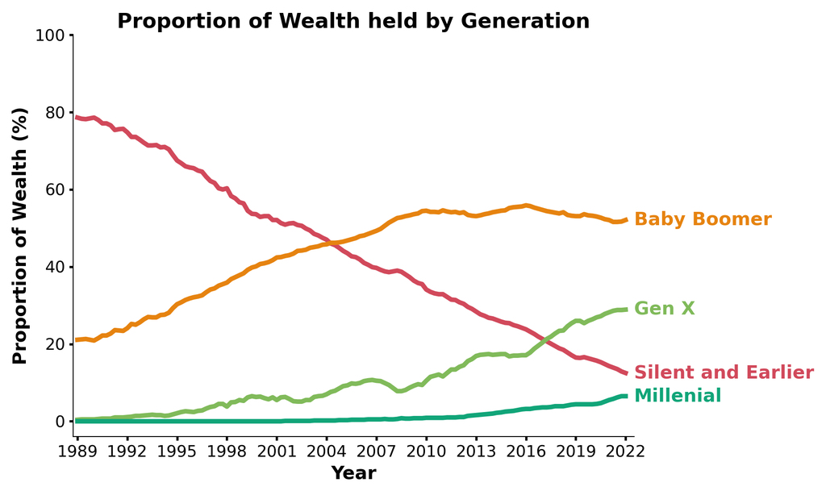

**About this Figure** (click me)**

## Who holds the most wealth?

### By Amount

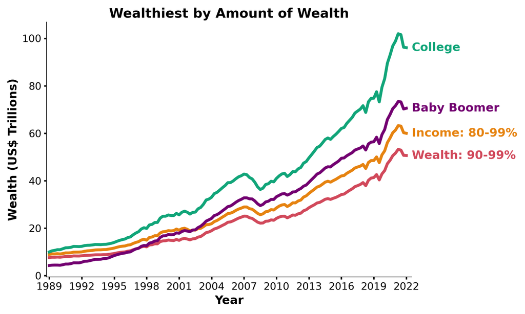

The figures above plot the wealthiest groups, on average, from each of the data sets we’ve examined above. While many factors contribute to these values and the groups are not mutually exclusive, these figures give a sense of the most important characteristics related to wealth in the US.

### By Proportion

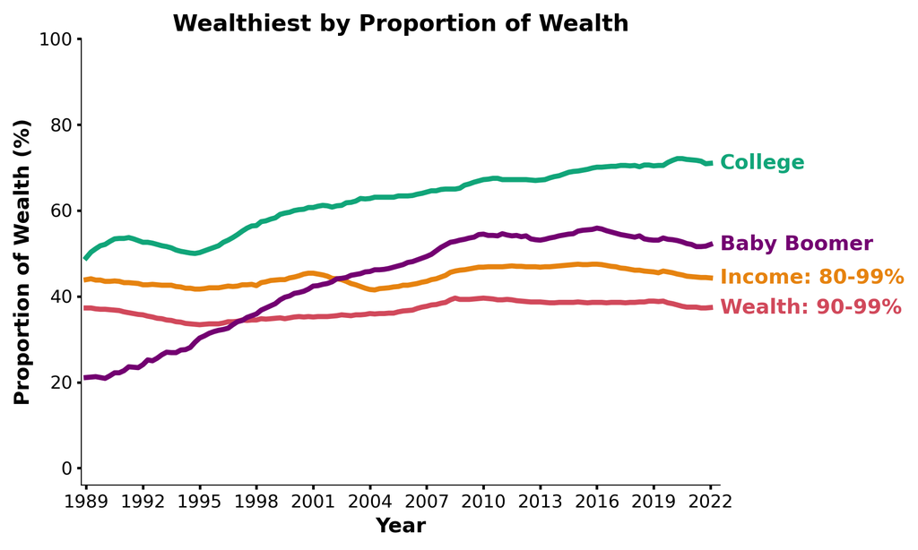

The figures above plot the wealthiest groups, on average, from each of the data sets we’ve examined above. While many factors contribute to these values and the groups are not mutually exclusive, these figures give a sense of the most important characteristics related to wealth in the US.

## Final Remarks

In each of the visuals above we explored key characteristics contributing to wealth in the US over the last 33 years. All together, it’s clear the college-educated and those in the Baby Boomer generation consistently held a significant proportion of the wealth in this country. We also observed large disparities in wealth when it comes to examining both income and wealth percentiles, with those in the 50th percentile and below holding less 15% of nation’s wealth across both metrics.

## About this Project

This collaborative project was created in Jupyter Notebooks and R. We used Jupyter Notebooks to process the data and develop the visualizations. Then, we used python within R Markdown to design and render this page as HTML. You can find the source code for this project in on our Github. Data for this project comes from the US Census Bureau, curated by the [Lonely Octopus team](https://www.lonelyoctopus.com/) as part of a data challenge.

Thanks for taking the time to check out our project! If you have any questions feel free to engage with us on LinkedIn.

## The Authors

### Jessica Hooker

#### [Linkedin](https://www.linkedin.com/in/jessica-hooker-phd)

#### [Github](https://github.com/j-hook)

### Erica Luong

#### [Linkedin](https://www.linkedin.com/in/ericaaluong)

#### [Github](https://github.com/ericaluong/)

### Jeremy Tran

#### [Linkedin](https://www.linkedin.com/in/jeremy-tran-501503246/)

#### [Github](https://github.com/fishingboatman)